# Spatio-temporal dynamics is for the birds

### Tensor interaction smooths

There are many cases when we want an estimate of both the average effect of each variable as well as the interaction. This is tough to extract from just using `te()` terms, but if we try to combine the two (say, with `y~s(x1)+s(x2)+te(x1,x2))`) the result is often numerically unstable; it won’t give reliable consistent separation into the terms we want. Instead, we use `ti` terms for the interaction. The `ti` terms are set up so the average effect of each variable in the smooth is already excluded from the interaction (and they’ll have fewer basis functions than the equivalent `te` term). Search `?te` if you’re curious about how `mcgv` sets these up; for now, we’ll just use them as a black box.

This is how you use them in practice:

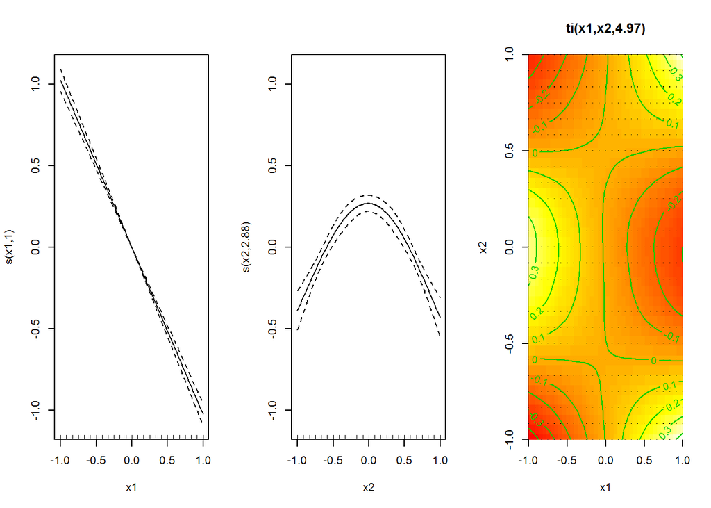

```r
# We'll recycle our fake tensor product as the expected value for a simulation
# Waste not, want not!

ti_demo = gam(y~s(x1,k=4)+s(x2,k=4) +ti(x1, x2, k = 4^2),
              data=dat,method="REML")
layout(matrix(1:3,nrow=1))
plot.gam(ti_demo,scheme = 2)
```

```r
layout(1)
summary(ti_demo)
```

```
##
## Family: gaussian
## Link function: identity
##
## Formula:
## y ~ s(x1, k = 4) + s(x2, k = 4) + ti(x1, x2, k = 4^2)
##
## Parametric coefficients:
##             Estimate Std. Error t value Pr(>|t|)
## (Intercept) 0.007125   0.020432   0.349    0.727
##
## Approximate significance of smooth terms:
##             edf Ref.df       F  p-value
## s(x1)     1.000  1.000 905.666  < 2e-16 ***
## s(x2)     2.877  2.988  40.383  < 2e-16 ***
## ti(x1,x2) 4.974  7.007   8.119 1.71e-09 ***
## ---
## Signif. codes:  0 '***' 0.001 '**' 0.01 '*' 0.05 '.' 0.1 ' ' 1
##
## R-sq.(adj) =  0.634   Deviance explained = 63.9%
## -REML = 480.88  Scale est. = 0.26091   n = 625
```

```r
print(ti_demo$sp)
```

```
##        s(x1)        s(x2)   ti(x1,x2)1   ti(x1,x2)2
## 4.948923e+04 1.025638e-01 3.806145e+02 2.595332e+00
```

```r
#These are the estimated smooths for the two dimensions. Note that the smooth for
#x1 (the linear basis) is way smoother than the one for x2
```

Note that it does a pretty good job of extracting our assumed marginal basis functions (linear and Gaussian) and the tensor product into three clearly separate functions.

NOTE: Never use `ti` on its own without including the marginal smooths! This is for the same reason you shouldn’t exclude individual linear terms but include interactions in `glm` models. It really virtually never makes sense to talk about a function with a strong interaction but not marginal effects.

### Random effects smooths

The last smooth type we’ll use in this exercise is the random effects smooth. This is just what it sounds on the box: it’s a smooth for factor terms, with one coefficient for each level of the group (the basis functions for this case), and a penalty term on the squared value of the coefficients to draw them towards the global mean. This is exactly the same mechanism that packages like `lme4` and `nlme` use to calculate random effects. In fact, there’s a very deep connection between gams and mixed effects,but we won’t go into that here.

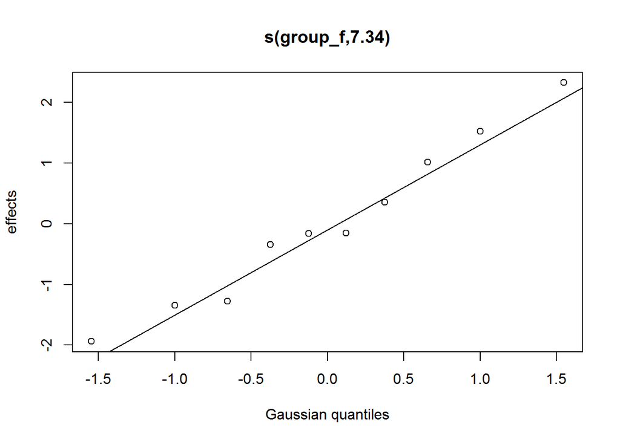

```r
n= 10
n_groups= 10
group_means = rnorm(n_groups, 0, 2)
dat = data_frame(group = rep(1:n_groups, each=n),
                 group_f = factor(group))
dat$y = rnorm(n*n_groups, 3+group_means[dat$group],2)
re_demo = gam(y~s(group_f, bs="re"),
              data=dat,method="REML")
plot.gam(re_demo,scheme = 2)
```

```r
summary(re_demo)
```

```
##
## Family: gaussian
## Link function: identity
##
## Formula:
## y ~ s(group_f, bs = "re")
##
## Parametric coefficients:
##             Estimate Std. Error t value Pr(>|t|)
## (Intercept)   1.9075     0.5207   3.664 0.000416 ***
## ---
## Signif. codes:  0 '***' 0.001 '**' 0.01 '*' 0.05 '.' 0.1 ' ' 1
##
## Approximate significance of smooth terms:
##              edf Ref.df     F  p-value
## s(group_f) 7.342      9 4.429 4.37e-06 ***
## ---
## Signif. codes:  0 '***' 0.001 '**' 0.01 '*' 0.05 '.' 0.1 ' ' 1
##
## R-sq.(adj) =  0.287   Deviance explained =   34%
## -REML = 229.99  Scale est. = 4.9934    n = 100
```

```r
print(re_demo$sp)
```

```
## s(group_f)
##   2.257823
```

It’s important to know when using `bs="re"` terms whether the variable you’re giving it is numeric or factorial. `mgcv` will not raise an error if you give it numerical variables to `bs="re"`. Instead, it’ll just fit a linear model with a penalty on the slope of the line between x and y. Try it with the data about to see, by switching `s(group_f, bs="re")` with `s(group, bs="re")`. `bs="re"` is set up like this to allow you to use random effects smooths to fit things like varying slopes random effects models, but make sure you know what you’re doing when venturing into this.

## 3. Spatiotemporal models

Now that we’ve covered the key smoothers, let’s take a look at how we’d use them to model spatiotemporal data. For this section, we’ll use data from the Florida routes of the Breeding Bird Survey. If you haven’t heard of it before, this is a long-term monitoring program tracking bird abundance and diversity across the US and Canada. It consists of many (over 4000) 24.5 mile long routes. Trained observers walk these routes each year during peak breeding season, and every 0.5 miles, they stop and count and identify all the birds they can see or hear in a 0.25 mile radius of the stop. This is one of the best long-term data sets we have on bird diversity and abundance, and has been used in countless papers.

Here, we’re going to use this data to answer a couple relatively simple questions: how does bird species richness vary across the state of Florida, has average richness changed over time, and has the spatial pattern of richness varied? We obtained data from [this site](https://www.pwrc.usgs.gov/bbs/RawData/), and summarized it into the total number of different species and the total number of individual birds observed on each route in each year in the state of Florida.

First, we’ll load the data, and quickly plot it:

```r
library(maps)
florida_map = map_data("state","florida")%>%
  transmute(Longitude= long, Latitude = lat, order=order)
florida_birds = read.csv("data/bbs_data/bbs_florida_richness.csv")
head(florida_birds)
```

```
##   Year Route Latitude Longitude Richness Abundance
## 1 1966     2 30.37554 -86.27583       41       491
## 2 1966     3 30.51932 -86.48091       40       292
## 3 1966     4 30.52884 -85.13345       51       491
## 4 1966     6 30.59502 -84.04131       52       851
## 5 1966    10 30.27346 -83.85697       56       458
## 6 1966    11 29.66870 -83.37821       43       360
```

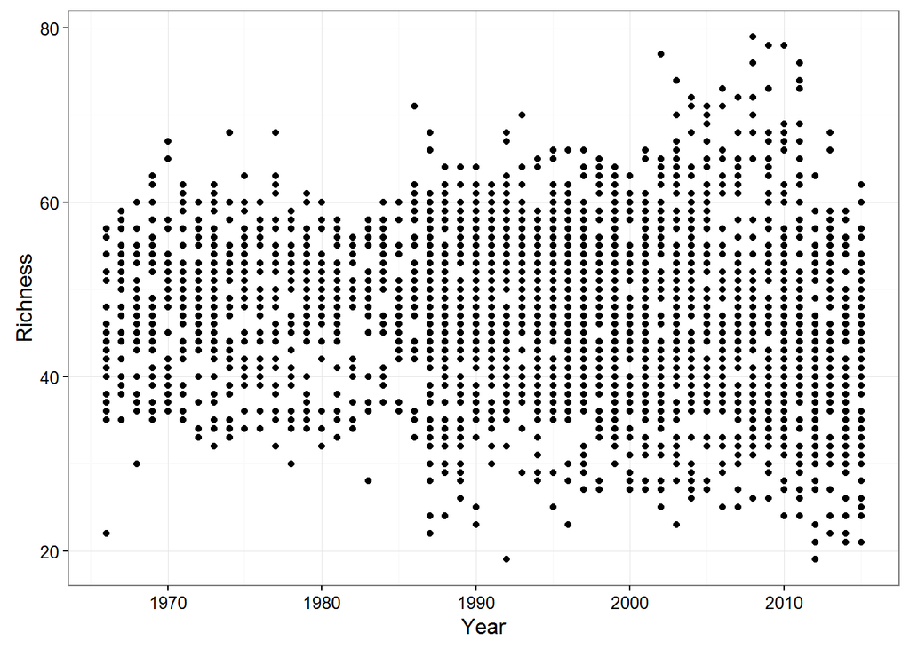

```r
ggplot(aes(x=Year,y=Richness),data=florida_birds)+geom_point()+
  theme_bw()
```

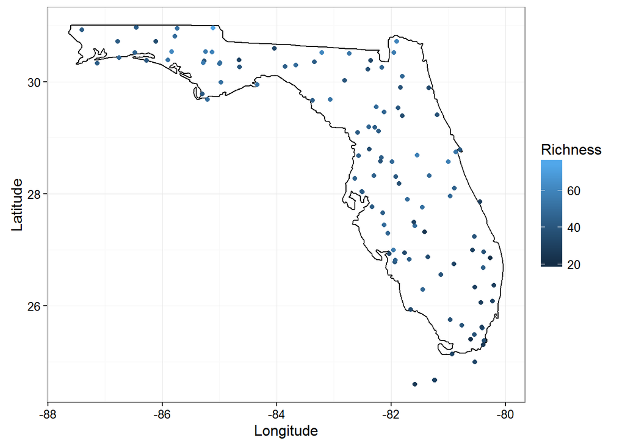

```r
ggplot(aes(x=Longitude,y=Latitude,col=Richness), data=florida_birds) +
    geom_polygon(data=florida_map,fill=NA, col="black")+
  geom_point()+theme_bw()
```

It looks like richness may have declined in the end of the time series, and there seems to be somewhat of a north-south richness gradient, but we need to model it to really tease these issues out.

### Modelling space and time seperately

We’ll first take a stab at this to determine if these mean trends actually come out of the model. As richness is a count variable we’ll use a Poisson gam to model it. This means that we’re assuming mean richness is the product of a smooth function of location and of date, with no interactions; E(richness) = exp(f(year))*exp(g(location)).

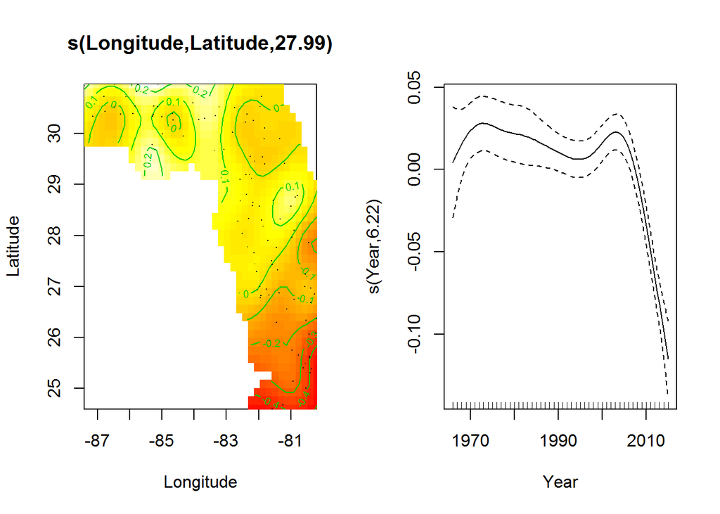

```r
richness_base_model = gam(Richness~ s(Longitude,Latitude)+s(Year),
                          data=florida_birds,family=poisson,method="REML")
layout(matrix(1:2,ncol=2))
plot(richness_base_model,scheme=2)
```

```r
layout(1)
summary(richness_base_model)
```

```
##
## Family: poisson
## Link function: log
##
## Formula:
## Richness ~ s(Longitude, Latitude) + s(Year)
##
## Parametric coefficients:
##             Estimate Std. Error z value Pr(>|z|)
## (Intercept) 3.843781   0.002767    1389   <2e-16 ***
## ---
## Signif. codes:  0 '***' 0.001 '**' 0.01 '*' 0.05 '.' 0.1 ' ' 1
##
## Approximate significance of smooth terms:
##                          edf Ref.df Chi.sq p-value
## s(Longitude,Latitude) 27.991  28.93   1984  <2e-16 ***
## s(Year)                6.224   7.37    145  <2e-16 ***
## ---
## Signif. codes:  0 '***' 0.001 '**' 0.01 '*' 0.05 '.' 0.1 ' ' 1
##
## R-sq.(adj) =  0.441   Deviance explained = 45.5%
## -REML = 9482.8  Scale est. = 1         n = 2824
```

Note that we do have a thin-plate interaction between longitude and latitude. This is assuming that the gradient should be equally smooth latitudinally and longitudinally. This may not be totally accurate, as the function seems to change faster latitudinally, but we’ll ignore that until the exercises at the bottom. The model seems to be doing pretty well; it captured the original patterns we saw, and explains a not-inconsiderable 45% of the deviance.

Let’s see if there’s any remaining spatiotemporal patterns though:

```r
source("code_snippets/quantile_resid.R")
```

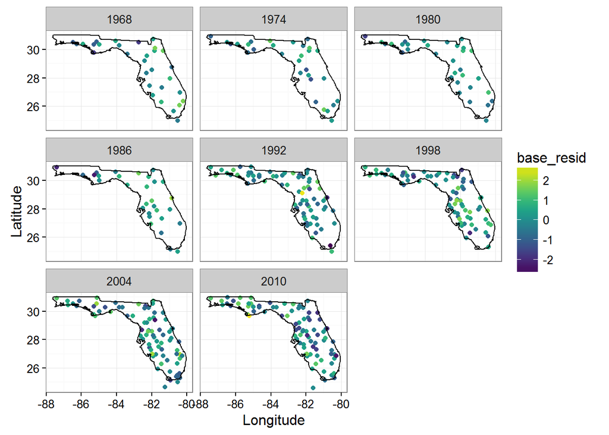

```r
florida_birds$base_resid = rqresiduals(richness_base_model)

ggplot(aes(Longitude, Latitude),
       data= florida_birds %>% filter(Year%%6==0))+ #only look at every 6th year
  geom_point(aes(color=base_resid))+
  geom_polygon(data=florida_map,fill=NA, col="black")+
  scale_color_viridis()+
  facet_wrap(~Year)+
  theme_bw()
```

There’s definitely still a pattern in the residuals, such as higher than expected diversity in the mid-latitudes during the 1990’s.

### Joint models of space and time

The next step is to determine if there is a significant interaction. This is where tensor product splines come in. Here, we’ll use the `ti` formulation, as it allows us to directly test whether the interaction significantly improves our model.

Something important to note: the `d=c(2,1)` argument it `ti`. This tells the function that the smooth should consist of tensor product between a 2-dimensional smooth (lat-long) and a 1-dimensional term (Year).

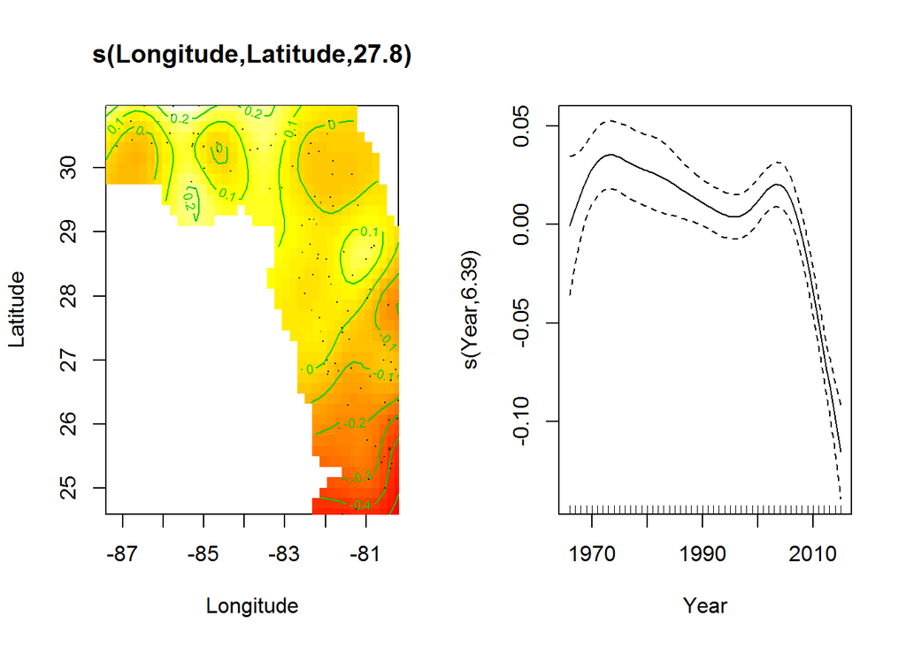

```r
richness_ti_model = gam(Richness~ s(Longitude,Latitude)+s(Year) +
                          ti(Longitude, Latitude, Year, d=c(2,1)),
                          data=florida_birds,family=poisson,method="REML")
layout(matrix(1:2,ncol=2))
plot(richness_ti_model,scheme=2)
```

```r
layout(1)
summary(richness_ti_model)
```

```
##
## Family: poisson
## Link function: log
##
## Formula:
## Richness ~ s(Longitude, Latitude) + s(Year) + ti(Longitude, Latitude,
##     Year, d = c(2, 1))
##
## Parametric coefficients:
##             Estimate Std. Error z value Pr(>|z|)
## (Intercept) 3.843686   0.002854    1347   <2e-16 ***
## ---
## Signif. codes:  0 '***' 0.001 '**' 0.01 '*' 0.05 '.' 0.1 ' ' 1
##
## Approximate significance of smooth terms:
##                               edf Ref.df Chi.sq p-value
## s(Longitude,Latitude)       27.80 28.849 1975.5  <2e-16 ***
## s(Year)                      6.39  7.524  140.7  <2e-16 ***
## ti(Longitude,Latitude,Year) 59.50 72.931  419.4  <2e-16 ***
## ---
## Signif. codes:  0 '***' 0.001 '**' 0.01 '*' 0.05 '.' 0.1 ' ' 1
##
## R-sq.(adj) =  0.533   Deviance explained = 55.1%
## -REML = 9347.6  Scale est. = 1         n = 2824
```

This improves the model fit substantially, which you can see by directly comparing models with `anova`:

```r
anova(richness_base_model,richness_ti_model,test = "Chisq")
```

```
## Analysis of Deviance Table
##
## Model 1: Richness ~ s(Longitude, Latitude) + s(Year)
## Model 2: Richness ~ s(Longitude, Latitude) + s(Year) + ti(Longitude, Latitude,
##     Year, d = c(2, 1))
##   Resid. Df Resid. Dev     Df Deviance  Pr(>Chi)
## 1    2788.8     2747.0
## 2    2729.3     2262.4 59.472   484.52 < 2.2e-16 ***
## ---
## Signif. codes:  0 '***' 0.001 '**' 0.01 '*' 0.05 '.' 0.1 ' ' 1
```

The question then becomes: what does this actually mean? Where are we seeing the fastest and slowest rates of change in richness? It’s often difficult to effectively show spatiotemporal changes, partially as it would require a 4-dimensional graph to really show what’s going on. Still, we can look at a couple different views by using `predict` effectively:

```r
#First we'll create gridded data
predict_richess = expand.grid(
  Latitude= seq(min(florida_birds$Latitude),
                max(florida_birds$Latitude),
                length=50),
  Longitude = seq(min(florida_birds$Longitude),
                  max(florida_birds$Longitude),
                  length=50),
  Year = seq(1970,2015,by=5)
)
# This now selects only that data that falls within Florida's border
predict_richess = predict_richess[with(predict_richess,
                                       inSide(florida_map, Latitude,Longitude)),]
```

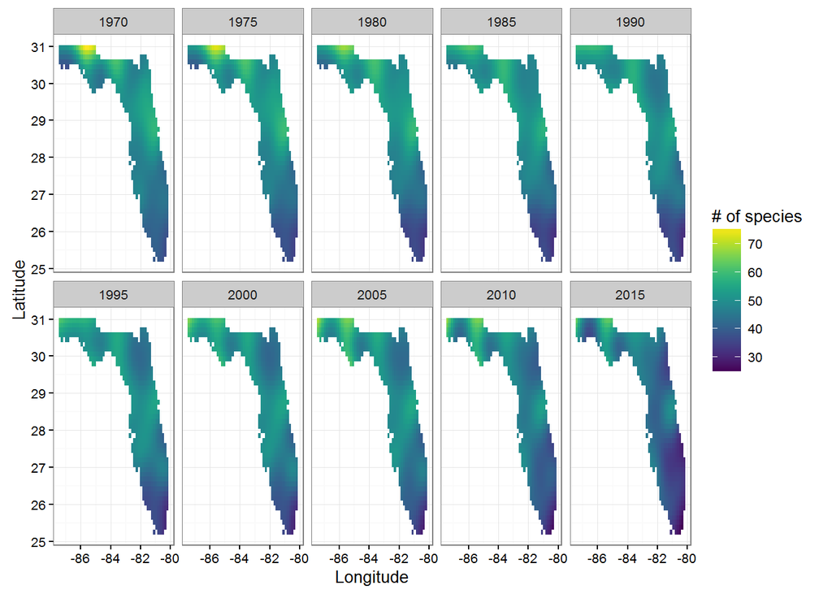

```r
predict_richess$model_fit = predict(richness_ti_model,
                                    predict_richess,type = "response")
ggplot(aes(Longitude, Latitude, fill= model_fit),
       data=predict_richess)+
  geom_tile()+
  facet_wrap(~Year,nrow=2)+
  scale_fill_viridis("# of species")+
  theme_bw(10)
```

Another way of looking at this is by estimating the rate of change at each location at each time point, and figuring out which locations are changing most quickly:

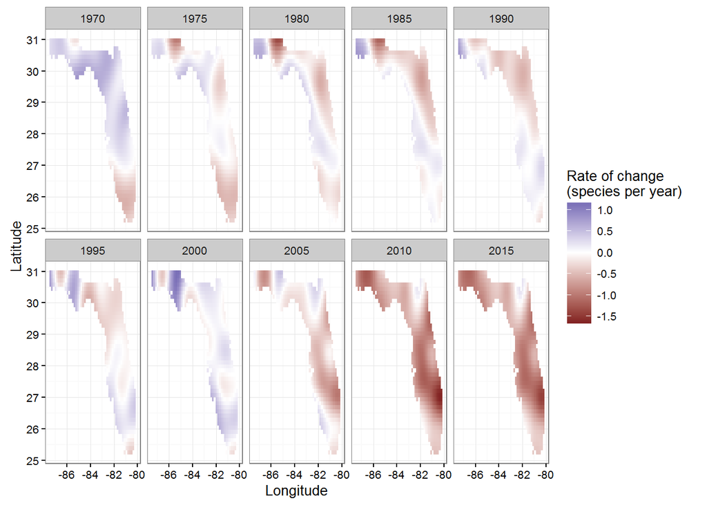

```r
predict_richess$model_change =predict(richness_ti_model,
                                      predict_richess%>%mutate(Year=Year+1),
                                      type = "response") -
  predict_richess$model_fit
ggplot(aes(Longitude, Latitude, fill= model_change),
       data=predict_richess)+
  geom_tile()+
  facet_wrap(~Year,nrow=2)+
  scale_fill_gradient2("Rate of change\n(species per year)")+
  theme_bw(10)
```

### Accounting for local heterogeneity with `bs="re"`

Examining this, it seems to indicate that richness fluctuated across the state throughout the study period, but then began sharply declining state-wide in the 2000’s. (Disclaimer: I don’t know enough about either the BBS or Florida to say how much of this decline is real! Please don’t quote me in newspapers saying biodiversity is collapsing in Florida).

There is still one persistent issue: viewing the maps of richness, there appear to be small hotspots and coldspots of richness across the state. This may be due to a factor I’ve ignored so far: the data is collected in specific, repeated routes. If it’s just easier to spot birds on one route, or there’s a lot of local nesting habitat there, it will have higher richness than expected over the whole study. Adjusting for these kinds of hot and cold spots will force our model to be overly wiggly. Further, not all routes are sampled every year, so we want to make sure that our trends don’t just result from less diverse routes getting sampled later in the survey.

To try and account for this effect (and other grouped local factors), we can use random effects smooths. That would make our model look like this:

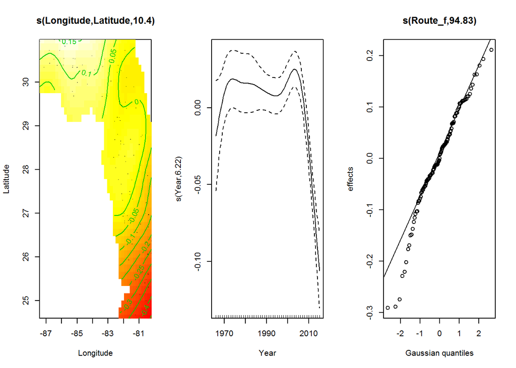

```r
florida_birds$Route_f = factor(florida_birds$Route)
richness_ti_re_model = gam(Richness~ s(Longitude,Latitude)+s(Year) +
                          ti(Longitude, Latitude, Year, d=c(2,1))+
                          s(Route_f, bs="re"),
                          data=florida_birds,family=poisson,method="REML")
layout(matrix(1:3,nrow=1))
plot(richness_ti_re_model,scheme=2)
```

```r
layout(1)

summary(richness_ti_re_model)
```

```
##
## Family: poisson
## Link function: log
##
## Formula:
## Richness ~ s(Longitude, Latitude) + s(Year) + ti(Longitude, Latitude,
##     Year, d = c(2, 1)) + s(Route_f, bs = "re")
##
## Parametric coefficients:
##             Estimate Std. Error z value Pr(>|z|)
## (Intercept)  3.83270    0.01086   352.8   <2e-16 ***
## ---
## Signif. codes:  0 '***' 0.001 '**' 0.01 '*' 0.05 '.' 0.1 ' ' 1
##
## Approximate significance of smooth terms:
##                               edf  Ref.df Chi.sq p-value
## s(Longitude,Latitude)       10.40  10.854  145.1  <2e-16 ***
## s(Year)                      6.22   7.363  104.5  <2e-16 ***
## ti(Longitude,Latitude,Year) 54.24  67.166  345.6  <2e-16 ***
## s(Route_f)                  94.83 120.000  904.6  <2e-16 ***
## ---
## Signif. codes:  0 '***' 0.001 '**' 0.01 '*' 0.05 '.' 0.1 ' ' 1
##
## R-sq.(adj) =  0.697   Deviance explained = 71.6%
## -REML = 9054.2  Scale est. = 1         n = 2824
```

```r
anova(richness_ti_model,richness_ti_re_model)
```

```
## Analysis of Deviance Table
##
## Model 1: Richness ~ s(Longitude, Latitude) + s(Year) + ti(Longitude, Latitude,
##     Year, d = c(2, 1))
## Model 2: Richness ~ s(Longitude, Latitude) + s(Year) + ti(Longitude, Latitude,
##     Year, d = c(2, 1)) + s(Route_f, bs = "re")
##   Resid. Df Resid. Dev     Df Deviance
## 1    2729.3     2262.4
## 2    2657.3     1429.0 72.009   833.47
```

We can view the same plots as before with our new model:

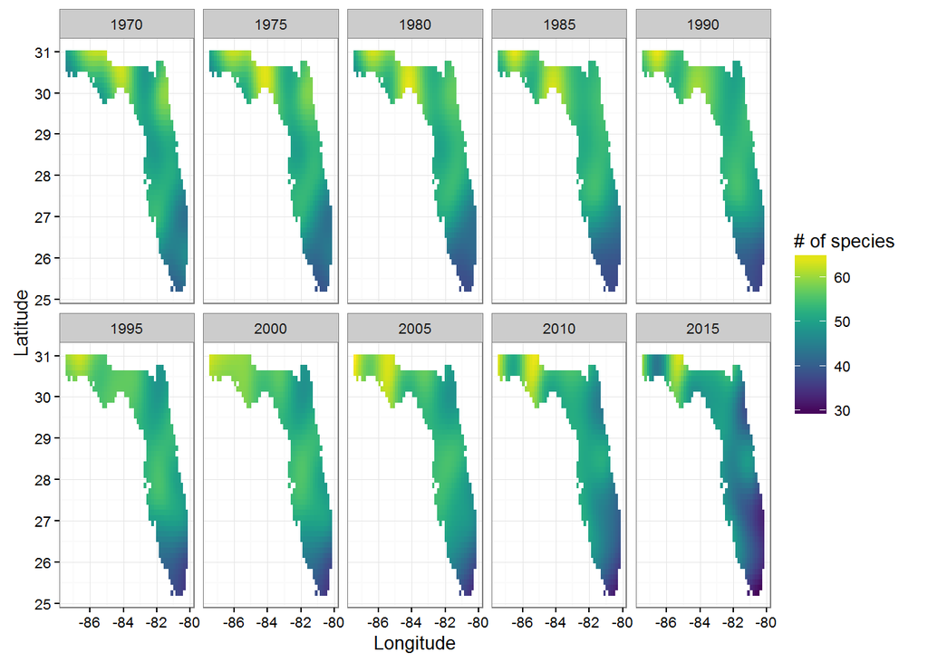

```r
predict_richess$Route_f = 1
predict_richess$model_fit = predict(richness_ti_re_model,
                                    predict_richess,type = "response")
predict_richess$model_change =predict(richness_ti_re_model,
                                      predict_richess%>%mutate(Year=Year+1),
                                      type = "response") -
  predict_richess$model_fit

ggplot(aes(Longitude, Latitude, fill= model_fit),
       data=predict_richess)+
  geom_tile()+
  facet_wrap(~Year,nrow=2)+
  scale_fill_viridis("# of species")+
  theme_bw(10)
```

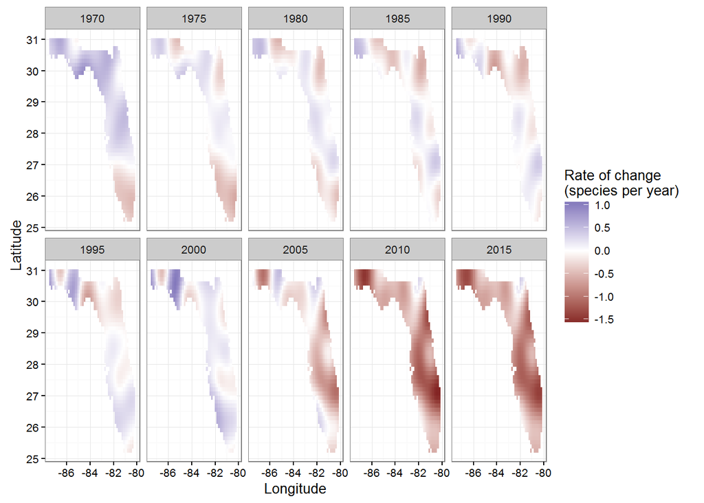

```r
ggplot(aes(Longitude, Latitude, fill= model_change),
       data=predict_richess)+
  geom_tile()+
  facet_wrap(~Year,nrow=2)+
  scale_fill_gradient2("Rate of change\n(species per year)")+
  theme_bw(10)
```

This definely seems to have levelled off some of the hot spots from before, implying that bird richness is more evenly distributed than our prior model suggested. Still, the large-scale trends remain the same from before.

## 4. Exercises

1. Given that most of the variability appears to be latitudinal, try to adapt the tensor smoothers so that latitude,longitude, and year all have their own penalty terms. How does this change model fit?
2. Following up on the prior exorcise: build a model that allows you to explicitly calculate the marginal latitudinal gradient in diversity, and to determine how the latitudinal gradient has changed over time.
3. We know from basic sampling theory that if you sample fewer individuals over time, you also expect to find lower richness, even if actual richness stays unchanged. What does the spatiotemporal pattern of abudance look like? Does adding bird abudance as a predictor explain any of the patterns in richness?